# Projekt

Frane Batagelj

13/12/2020

## Opis podataka

Učitajmo potrebne pakete.

```r
library(dplyr)
```

Učitajmo podatke.

```r
mutual_funds = read.csv("C:/Materijali/SAP/Projekt/mutual_funds.csv")
dim(mutual_funds)
```

```
## [1] 6386   98
```

```r
names(mutual_funds)
```

```
##  [1] "fund_name"                           "fund_extended_name"
##  [3] "category"                            "fund_family"
##  [5] "net_assets"                          "ytd_return"
##  [7] "fund_yield"                          "morningstar_rating"
##  [9] "inception_date"                      "investment"
## [11] "size"                                "currency"
## [13] "net_annual_expense_ratio_fund"       "net_annual_expense_ratio_category"
## [15] "portfolio_cash"                      "portfolio_stocks"
## [17] "portfolio_preferred"                 "price_earnings"
## [19] "price_book"                          "price_sales"
## [21] "price_cashflow"                      "median_market_cap"
## [23] "basic_materials"                     "consumer_cyclical"
## [25] "financial_services"                  "real_estate"
## [27] "consumer_defensive"                  "healthcare"
## [29] "utilities"                           "communication_services"
```

[output cut: 34 more lines]

```r
mutual_funds = select(mutual_funds,c("fund_name","category","net_annual_expense_ratio_fund","net_annual_expense_ratio_category","fund_return_10years","category_return_10years","morningstar_rating","net_assets", "investment", "price_earnings"))
dim(mutual_funds)
```

```
## [1] 6386   10
```

```r
summary(mutual_funds)
```

```
##   fund_name           category         net_annual_expense_ratio_fund
##  Length:6386        Length:6386        Min.   :0.000
##  Class :character   Class :character   1st Qu.:0.840
##  Mode  :character   Mode  :character   Median :1.090
##                                        Mean   :1.179
##                                        3rd Qu.:1.440
##                                        Max.   :8.950
##
##  net_annual_expense_ratio_category fund_return_10years category_return_10years
##  Min.   :0.750                     Min.   :-14.06      Min.   :-2.95
##  1st Qu.:1.010                     1st Qu.: 11.71      1st Qu.:12.77
##  Median :1.110                     Median : 14.08      Median :14.51
##  Mean   :1.123                     Mean   : 13.35      Mean   :13.59
##  3rd Qu.:1.200                     3rd Qu.: 15.71      3rd Qu.:15.70
##  Max.   :2.170                     Max.   : 24.21      Max.   :18.72
##
##  morningstar_rating   net_assets         investment        price_earnings
##  Min.   :0.000      Min.   :3.977e+05   Length:6386        Min.   : 0.00
##  1st Qu.:2.000      1st Qu.:2.197e+08   Class :character   1st Qu.:13.36
##  Median :3.000      Median :7.930e+08   Mode  :character   Median :15.69
##  Mean   :3.006      Mean   :3.496e+09                      Mean   :17.27
##  3rd Qu.:4.000      3rd Qu.:2.410e+09                      3rd Qu.:19.28
##  Max.   :5.000      Max.   :1.131e+11                      Max.   :62.62
##                     NA's   :2
```

```r
sapply(mutual_funds,class)
```

```
##                         fund_name                          category
##                       "character"                       "character"
##     net_annual_expense_ratio_fund net_annual_expense_ratio_category
##                         "numeric"                         "numeric"
##               fund_return_10years           category_return_10years
##                         "numeric"                         "numeric"
##                morningstar_rating                        net_assets
##                         "integer"                         "numeric"
##                        investment                    price_earnings
##                       "character"                         "numeric"
```

Paziti na ove kad se gleda morningstar_rating

```r
mutual_funds$morningstar_rating = as.factor(mutual_funds$morningstar_rating)
mutual_funds$category = as.factor(mutual_funds$category)
mutual_funds[mutual_funds$morningstar_rating==0,]
```

```
##      fund_name      category net_annual_expense_ratio_fund
## 1512     FDPIX Multicurrency                          1.78
## 1513     FDPSX Multicurrency                          2.78
## 4966     RDPIX Multicurrency                          1.78
## 4967     RDPSX Multicurrency                          2.78
##      net_annual_expense_ratio_category fund_return_10years
## 1512                              1.29               -3.13
## 1513                              1.29               -4.07
## 4966                              1.29               -0.44
## 4967                              1.29               -1.43
##      category_return_10years morningstar_rating net_assets  investment
## 1512                    0.28                  0    3950000 <undefined>
## 1513                    0.28                  0    3950000 <undefined>
## 4966                    0.28                  0   15870000 <undefined>
## 4967                    0.28                  0   15870000 <undefined>
##      price_earnings
## 1512              0
## 1513              0
## 4966              0
## 4967              0
```

```r
mutual_funds <- subset(mutual_funds, mutual_funds$morningstar_rating != 0)
```

Tražimo nepoznate podatke

```r
imaNedostajucih = 0;
for (col_name in names(mutual_funds)){
  if (sum(is.na(mutual_funds[,col_name])) > 0){
    cat('Ukupno nedostajućih vrijednosti za varijablu ',col_name, ': ', sum(is.na(mutual_funds[,col_name])),'\n')
    imaNedostajucih = 1;
  }
}
```

```
## Ukupno nedostajucih vrijednosti za varijablu  net_assets :  2
```

```r
if(!imaNedostajucih) {
  cat("Nema nedostajucih podataka")
}

cat('\nDimenzija podataka: ', dim(mutual_funds))
```

```
##
## Dimenzija podataka:  6382 10
```

Pogledamo podatke koje imamo

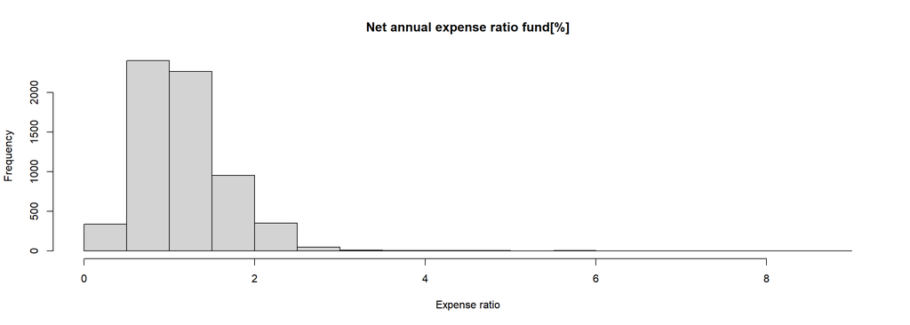

```r
hist(mutual_funds$net_annual_expense_ratio_fund,main='Net annual expense ratio fund[%]', xlab='Expense ratio', ylab='Frequency')
```

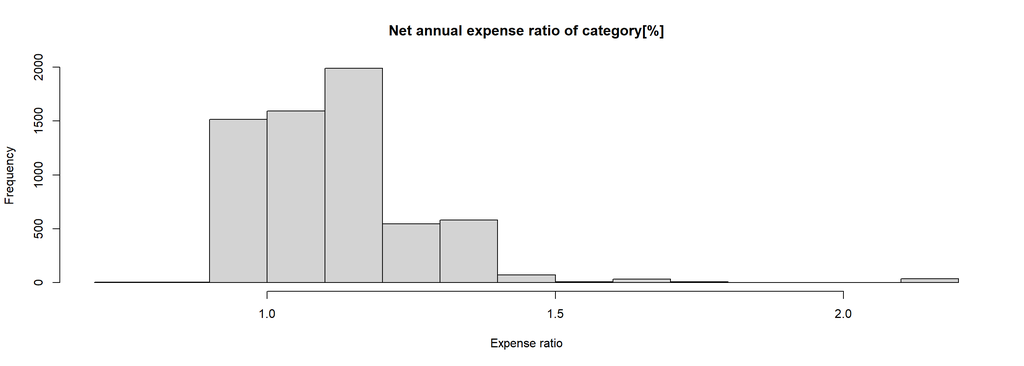

```r
hist(mutual_funds$net_annual_expense_ratio_category,main='Net annual expense ratio of category[%]', xlab='Expense ratio', ylab='Frequency')
```

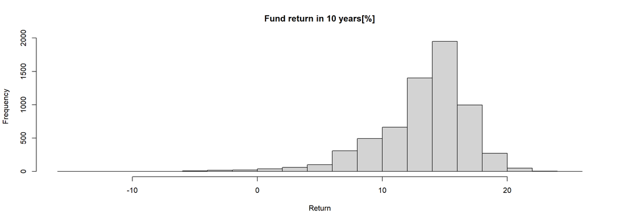

```r
hist(mutual_funds$fund_return_10years,main='Fund return in 10 years[%]', xlab='Return', ylab='Frequency')
```

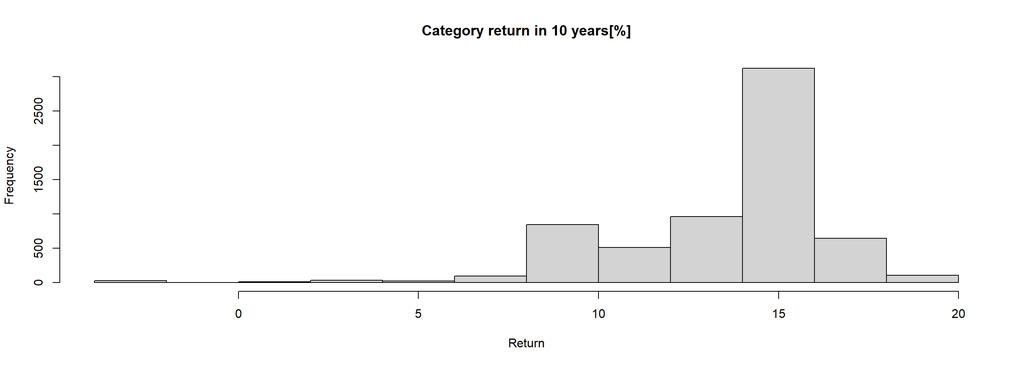

```r
hist(mutual_funds$category_return_10years,main='Category return in 10 years[%]', xlab='Return', ylab='Frequency')
```

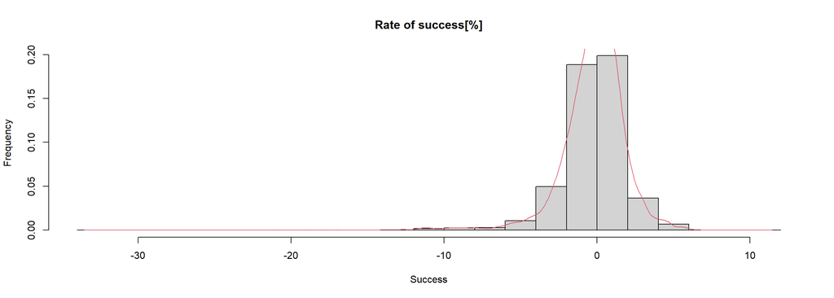

```r
mutual_funds <- mutual_funds %>% mutate(success = fund_return_10years - category_return_10years)
hist(mutual_funds$success,probability=T,main='Rate of success[%]', xlab='Success', ylab='Frequency',breaks = 20)
lines(density(mutual_funds$success), col = 2)
```

```r
dim(mutual_funds)
```

```
## [1] 6382   11
```

Provjerimo kategorijske podatke

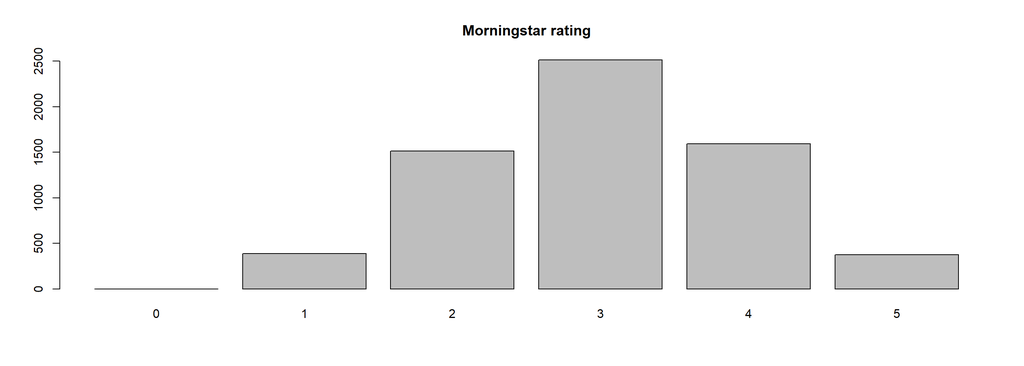

```r
barplot(summary(mutual_funds$morningstar_rating),main='Morningstar rating')
```

POdjela na grupu s outlierima i bez outliera

```r
mutual_funds_outliers <- mutual_funds
Q <- quantile(mutual_funds$success, probs=c(.25, .75), na.rm = FALSE)
iqr <- IQR(mutual_funds$success)
mutual_funds <- subset(mutual_funds, mutual_funds$success > (Q[1] - 1.5*iqr) & mutual_funds$success < (Q[2]+1.5*iqr))
```

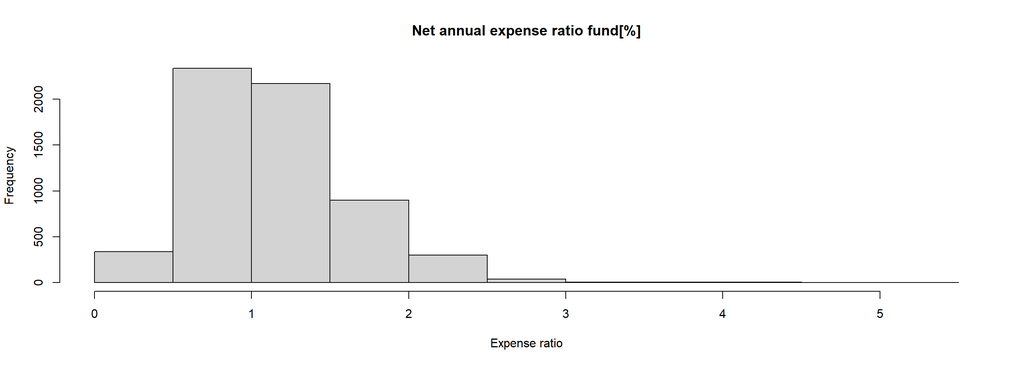

```r
hist(mutual_funds$net_annual_expense_ratio_fund,main='Net annual expense ratio fund[%]', xlab='Expense ratio', ylab='Frequency')
```

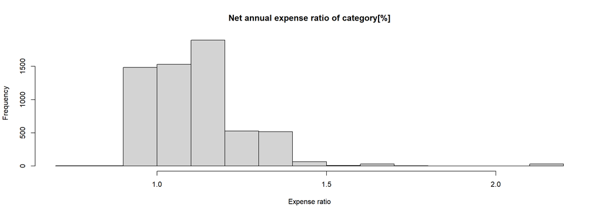

```r
hist(mutual_funds$net_annual_expense_ratio_category,main='Net annual expense ratio of category[%]', xlab='Expense ratio', ylab='Frequency')
```

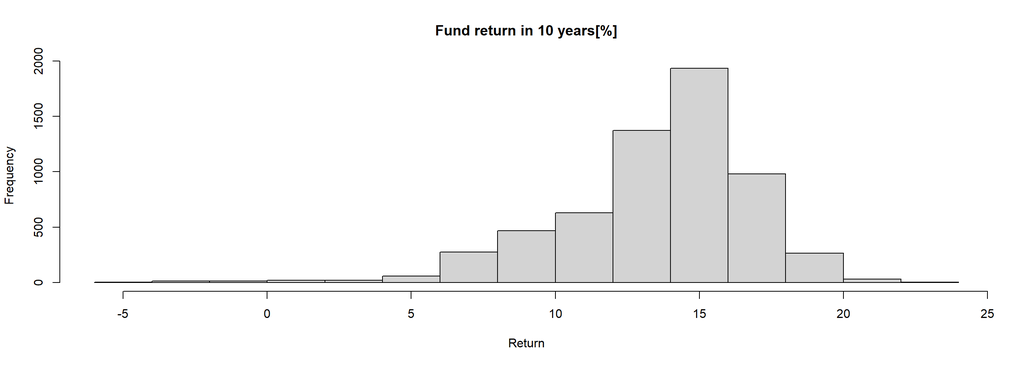

```r
hist(mutual_funds$fund_return_10years,main='Fund return in 10 years[%]', xlab='Return', ylab='Frequency')
```

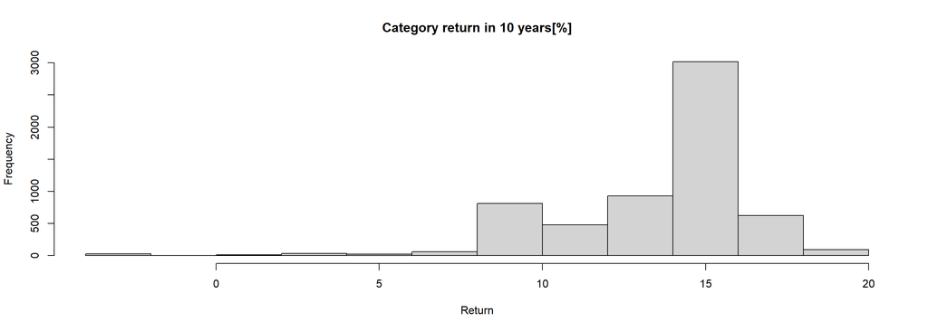

```r
hist(mutual_funds$category_return_10years,main='Category return in 10 years[%]', xlab='Return', ylab='Frequency')
```

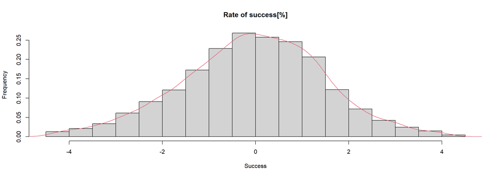

```r
hist(mutual_funds$success,probability=T,main='Rate of success[%]', xlab='Success', ylab='Frequency',breaks = 20)
lines(density(mutual_funds$success),col=2)
```

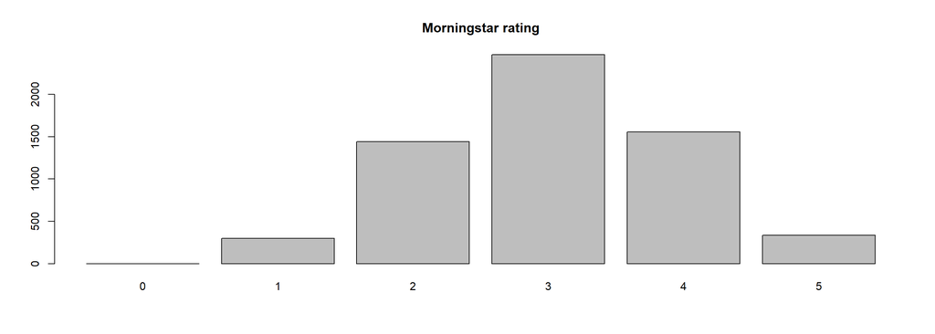

```r
barplot(summary(mutual_funds$morningstar_rating),main='Morningstar rating')
```

```r
dim(mutual_funds)
```

```
## [1] 6097   11
```

Podjela na “skupe” i “jeftine” fondove

```r
mutual_funds_expensive = mutual_funds[mutual_funds$net_annual_expense_ratio_fund > mutual_funds$net_annual_expense_ratio_category,]
mutual_funds_cheap = mutual_funds[mutual_funds$net_annual_expense_ratio_fund <= mutual_funds$net_annual_expense_ratio_category,]

mutual_funds_outliers_expensive = mutual_funds_outliers[mutual_funds_outliers$net_annual_expense_ratio_fund > mutual_funds_outliers$net_annual_expense_ratio_category,]
mutual_funds_outliers_cheap = mutual_funds_outliers[mutual_funds_outliers$net_annual_expense_ratio_fund <= mutual_funds_outliers$net_annual_expense_ratio_category,]

summary(mutual_funds_expensive)
```

```
##   fund_name                      category    net_annual_expense_ratio_fund
##  Length:2769        Large Blend      : 336   Min.   :0.950
##  Class :character   Large Growth     : 326   1st Qu.:1.250
##  Mode  :character   Large Value      : 306   Median :1.460
##                     Small Blend      : 174   Mean   :1.559
##                     Small Growth     : 165   3rd Qu.:1.840
##                     World Large Stock: 161   Max.   :5.270
##                     (Other)          :1301
##  net_annual_expense_ratio_category fund_return_10years category_return_10years
##  Min.   :0.820                     Min.   :-5.49       Min.   :-2.95
##  1st Qu.:1.010                     1st Qu.:11.20       1st Qu.:11.79
##  Median :1.110                     Median :13.54       Median :14.51
##  Mean   :1.121                     Mean   :12.92       Mean   :13.42
##  3rd Qu.:1.200                     3rd Qu.:15.09       3rd Qu.:15.70
##  Max.   :2.170                     Max.   :21.63       Max.   :18.72
##
##  morningstar_rating   net_assets         investment        price_earnings
##  0:   0             Min.   :1.750e+06   Length:2769        Min.   : 0.00
##  1: 222             1st Qu.:1.432e+08   Class :character   1st Qu.:13.18
##  2: 881             Median :5.715e+08   Mode  :character   Median :15.23
##  3:1103             Mean   :2.640e+09                      Mean   :17.00
##  4: 479             3rd Qu.:1.750e+09                      3rd Qu.:18.88
##  5:  84             Max.   :1.131e+11                      Max.   :62.62
##
##     success
##  Min.   :-4.3600
##  1st Qu.:-1.5100
##  Median :-0.5200
##  Mean   :-0.5063
##  3rd Qu.: 0.4800
##  Max.   : 4.1300
##
```

```r
cat("\n")
```

```r
summary(mutual_funds_cheap)
```

```
##   fund_name                   category    net_annual_expense_ratio_fund
##  Length:3328        Large Growth  : 434   Min.   :0.0000
##  Class :character   Large Blend   : 425   1st Qu.:0.7000
##  Mode  :character   Large Value   : 417   Median :0.8500
##                     Small Growth  : 228   Mean   :0.8254
##                     Mid-Cap Growth: 223   3rd Qu.:0.9900
##                     Small Blend   : 218   Max.   :2.0100
##                     (Other)       :1383
##  net_annual_expense_ratio_category fund_return_10years category_return_10years
##  Min.   :0.750                     Min.   :-3.76       Min.   :-2.95
##  1st Qu.:1.000                     1st Qu.:12.82       1st Qu.:13.68
##  Median :1.110                     Median :14.76       Median :14.54
##  Mean   :1.118                     Mean   :14.13       Mean   :13.82
##  3rd Qu.:1.200                     3rd Qu.:16.08       3rd Qu.:15.94
##  Max.   :2.170                     Max.   :22.68       Max.   :18.72
##
##  morningstar_rating   net_assets         investment        price_earnings
##  0:   0             Min.   :1.370e+06   Length:3328        Min.   : 0.00
##  1:  76             1st Qu.:3.321e+08   Class :character   1st Qu.:13.51
##  2: 559             Median :1.080e+09   Mode  :character   Median :15.84
##  3:1366             Mean   :4.365e+09                      Mean   :17.46
##  4:1077             3rd Qu.:3.100e+09                      3rd Qu.:19.38
##  5: 250             Max.   :1.131e+11                      Max.   :50.51
##
##     success
##  Min.   :-4.3400
##  1st Qu.:-0.5300
##  Median : 0.3900
##  Mean   : 0.3095
##  3rd Qu.: 1.2200
##  Max.   : 4.1400
##
```

```r
cat("\n")
```

```r
summary(mutual_funds_outliers_expensive)
```

```
##   fund_name                      category    net_annual_expense_ratio_fund
##  Length:2948        Large Growth     : 355   Min.   :0.950
##  Class :character   Large Blend      : 348   1st Qu.:1.250
##  Mode  :character   Large Value      : 316   Median :1.470
##                     Small Blend      : 186   Mean   :1.586
##                     Small Growth     : 175   3rd Qu.:1.870
##                     World Large Stock: 169   Max.   :8.950
##                     (Other)          :1399
##  net_annual_expense_ratio_category fund_return_10years category_return_10years
##  Min.   :0.820                     Min.   :-14.06      Min.   :-2.95
##  1st Qu.:1.010                     1st Qu.: 10.61      1st Qu.:11.79
##  Median :1.110                     Median : 13.36      Median :14.51
##  Mean   :1.125                     Mean   : 12.58      Mean   :13.41
##  3rd Qu.:1.200                     3rd Qu.: 15.02      3rd Qu.:15.70
##  Max.   :2.170                     Max.   : 21.67      Max.   :18.72
##
##  morningstar_rating   net_assets         investment        price_earnings
##  0:   0             Min.   :3.977e+05   Length:2948        Min.   : 0.00
##  1: 301             1st Qu.:1.352e+08   Class :character   1st Qu.:13.19
##  2: 935             Median :5.440e+08   Mode  :character   Median :15.29
##  3:1125             Mean   :2.532e+09                      Mean   :17.01
##  4: 492             3rd Qu.:1.680e+09                      3rd Qu.:18.96
##  5:  95             Max.   :1.131e+11                      Max.   :62.62
##                     NA's   :2
##     success
##  Min.   :-32.780
##  1st Qu.: -1.752
##  Median : -0.590
##  Mean   : -0.833
##  3rd Qu.:  0.430
##  Max.   :  5.840
##
```

```r
cat("\n")
```

```r
summary(mutual_funds_outliers_cheap)
```

```
##   fund_name                   category    net_annual_expense_ratio_fund
##  Length:3434        Large Growth  : 449   Min.   :0.0000
##  Class :character   Large Blend   : 428   1st Qu.:0.7000
##  Mode  :character   Large Value   : 424   Median :0.8600
##                     Small Growth  : 232   Mean   :0.8293
##                     Mid-Cap Growth: 229   3rd Qu.:0.9900
##                     Small Blend   : 220   Max.   :2.1400
##                     (Other)       :1452
##  net_annual_expense_ratio_category fund_return_10years category_return_10years
##  Min.   :0.750                     Min.   :-5.19       Min.   :-2.95
##  1st Qu.:1.010                     1st Qu.:12.70       1st Qu.:13.31
##  Median :1.110                     Median :14.72       Median :14.54
##  Mean   :1.121                     Mean   :14.04       Mean   :13.77
##  3rd Qu.:1.200                     3rd Qu.:16.09       3rd Qu.:15.94
##  Max.   :2.170                     Max.   :24.21       Max.   :18.72
##
##  morningstar_rating   net_assets         investment        price_earnings
##  0:   0             Min.   :1.370e+06   Length:3434        Min.   : 0.00
##  1:  88             1st Qu.:3.295e+08   Class :character   1st Qu.:13.53
##  2: 579             Median :1.060e+09   Mode  :character   Median :15.87
##  3:1388             Mean   :4.328e+09                      Mean   :17.51
##  4:1099             3rd Qu.:3.100e+09                      3rd Qu.:19.58
##  5: 280             Max.   :1.131e+11                      Max.   :62.62
##
##     success
##  Min.   :-21.130
##  1st Qu.: -0.570
##  Median :  0.395
##  Mean   :  0.271
##  3rd Qu.:  1.250
##  Max.   : 10.680
##
```

Jesu li skuplji fondovi uspjesniji?

```r
cat('Prosječni uspjeh skupljih fondova bez outliera iznosi  ', mean(mutual_funds_expensive$success),'\n')
```

```
## Prosjecni uspjeh skupljih fondova bez outliera iznosi   -0.5062622
```

```r
cat('Prosječni uspjeh jeftinijih fondova bez outliera iznosi  ', mean(mutual_funds_cheap$success),'\n')
```

```
## Prosjecni uspjeh jeftinijih fondova bez outliera iznosi   0.3095493
```

```r
cat('Prosječni uspjeh skupljih fondova s outlierima iznosi  ', mean(mutual_funds_outliers_expensive$success),'\n')
```

```
## Prosjecni uspjeh skupljih fondova s outlierima iznosi   -0.833002
```

```r
cat('Prosječni uspjeh jeftinijih fondova s outlierima iznosi  ', mean(mutual_funds_outliers_cheap$success),'\n')
```

```
## Prosjecni uspjeh jeftinijih fondova s outlierima iznosi   0.2710425
```

```r
require(modeest)
cat('Prosječni rating skupljih fondova iznosi  ', mfv(mutual_funds_expensive$morningstar_rating),'\n')
```

[output not shown]

```r
cat('Prosječni rating jeftinijih fondova iznosi  ', mfv(mutual_funds_cheap$morningstar_rating),'\n')
```

[output not shown]

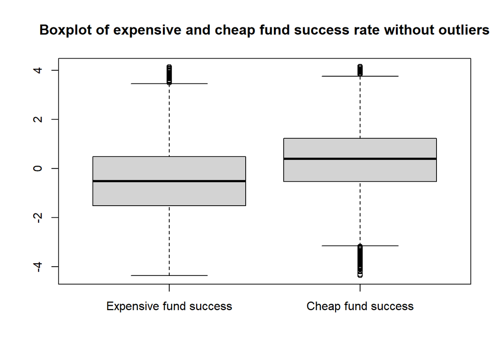

```r
boxplot(mutual_funds_expensive$success, mutual_funds_cheap$success,
        names = c('Expensive fund success','Cheap fund success'),
        main='Boxplot of expensive and cheap fund success rate without outliers')
```

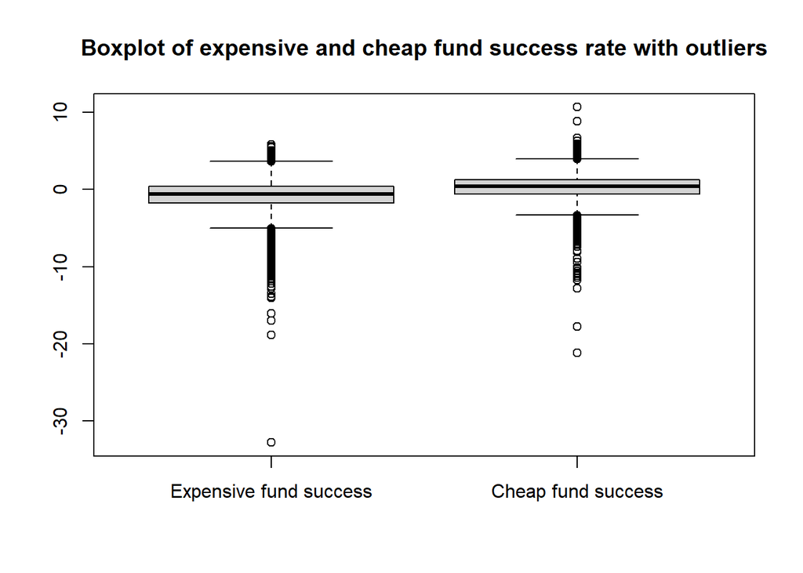

```r
boxplot(mutual_funds_outliers_expensive$success, mutual_funds_outliers_cheap$success,
        names = c('Expensive fund success','Cheap fund success'),
        main='Boxplot of expensive and cheap fund success rate with outliers')
```

Histogrami

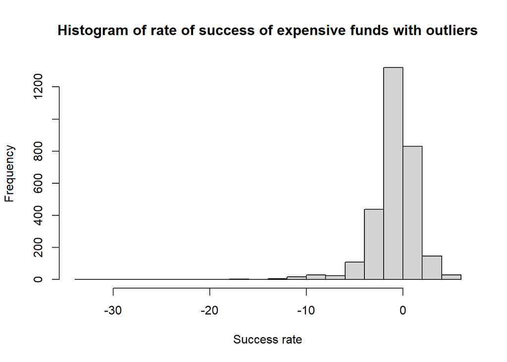

```r
hist(mutual_funds_outliers_expensive$success,
     breaks = 20,
     main='Histogram of rate of success of expensive funds with outliers',
     xlab='Success rate')
```

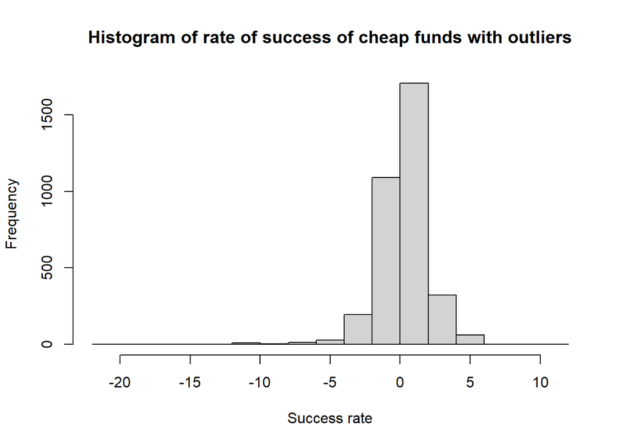

```r
hist(mutual_funds_outliers_cheap$success,
     main='Histogram of rate of success of cheap funds with outliers',
     xlab='Success rate')
```

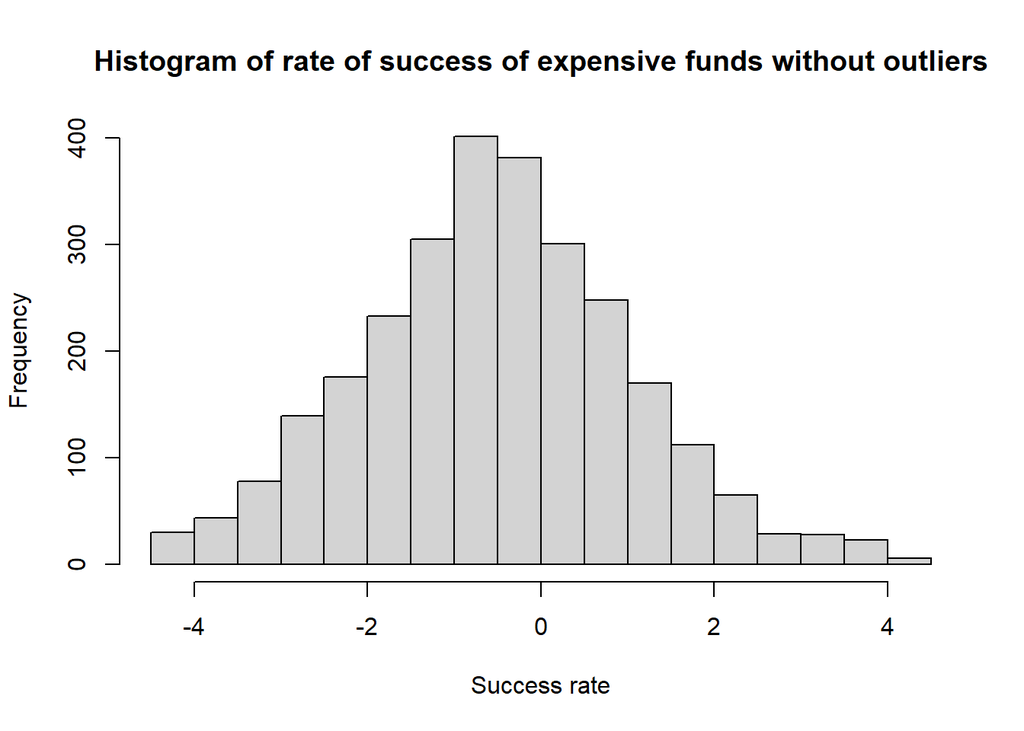

```r
hist(mutual_funds_expensive$success,
     breaks = 20,
     main='Histogram of rate of success of expensive funds without outliers',
     xlab='Success rate')
```

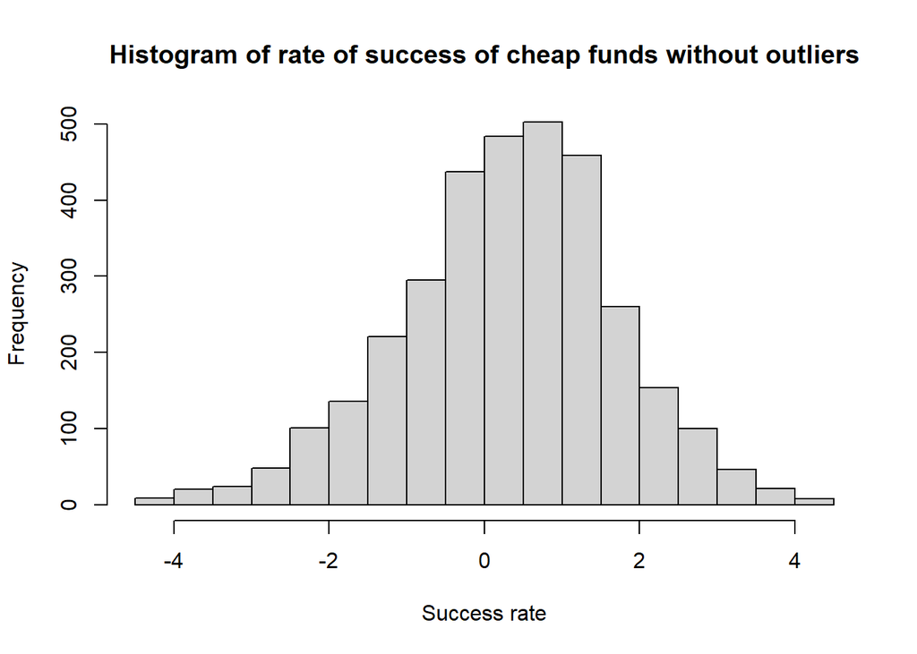

```r
hist(mutual_funds_cheap$success,
     main='Histogram of rate of success of cheap funds without outliers',
     xlab='Success rate')
```

Qq plotovi

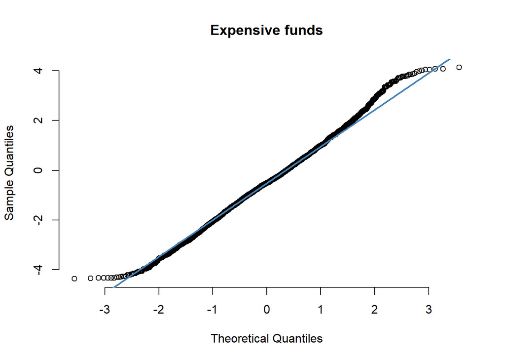

```r
qqnorm(mutual_funds_expensive$success, pch = 1, frame = FALSE,main='Expensive funds')
qqline(mutual_funds_expensive$success, col = "steelblue", lwd = 2)
```

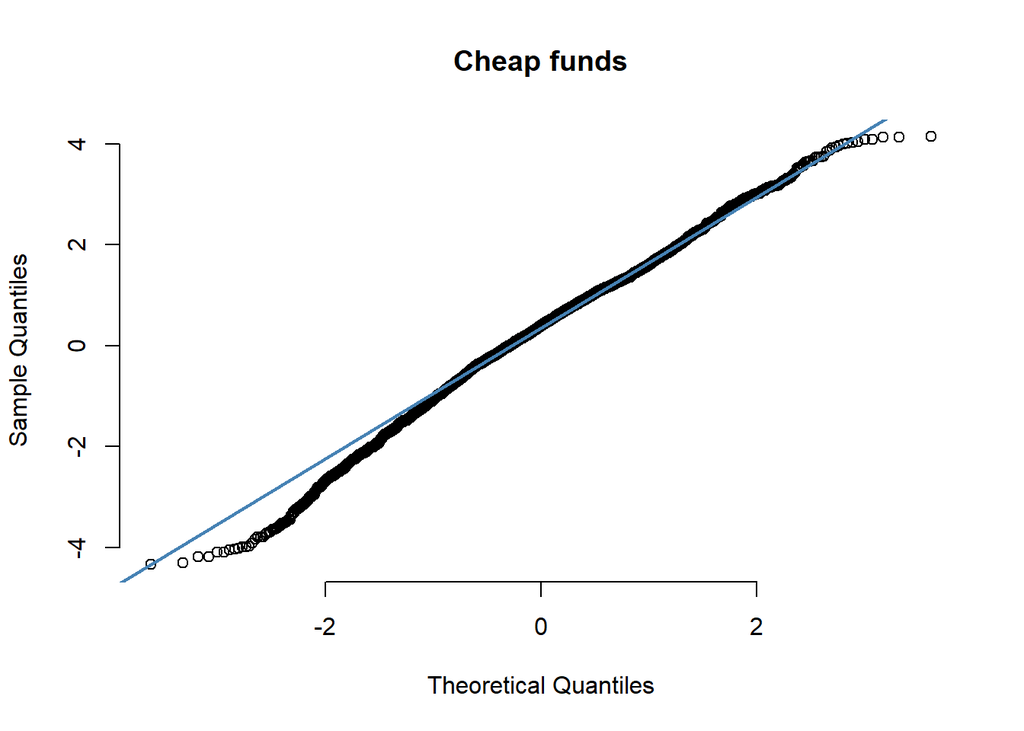

```r
qqnorm(mutual_funds_cheap$success, pch = 1, frame = FALSE,main='Cheap funds')
qqline(mutual_funds_cheap$success, col = "steelblue", lwd = 2)
```

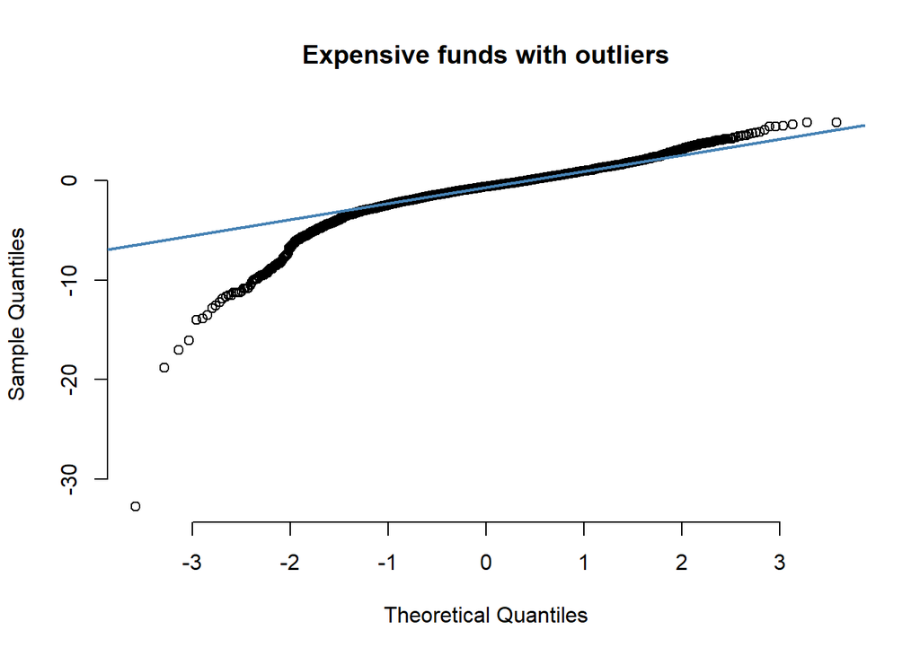

```r
qqnorm(mutual_funds_outliers_expensive$success, pch = 1, frame = FALSE,main='Expensive funds with outliers')
qqline(mutual_funds_outliers_expensive$success, col = "steelblue", lwd = 2)
```

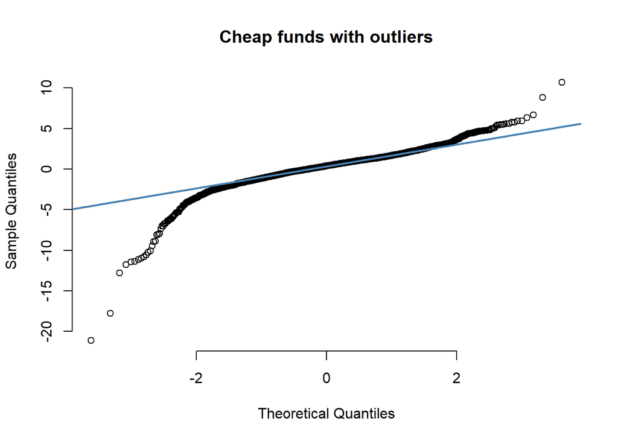

```r
qqnorm(mutual_funds_outliers_cheap$success, pch = 1, frame = FALSE,main='Cheap funds with outliers')
qqline(mutual_funds_outliers_cheap$success, col = "steelblue", lwd = 2)
```

Budući da imamo veliku kolićinu podataka, možemo pretpostaviti normalnost.

Provjeravamo normalnost

```r
library(nortest)
lillie.test(mutual_funds$success)
```

```
##
##  Lilliefors (Kolmogorov-Smirnov) normality test
##
## data:  mutual_funds$success
## D = 0.021208, p-value = 1.536e-06
```

```r
lillie.test(mutual_funds_outliers$success)
```

```
##
##  Lilliefors (Kolmogorov-Smirnov) normality test
##
## data:  mutual_funds_outliers$success
## D = 0.087033, p-value < 2.2e-16
```

## Ovo ne valja

Provjeravamo varijanice

```r
var(mutual_funds_expensive$success)
```

```
## [1] 2.405038
```

```r
var(mutual_funds_cheap$success)
```

```
## [1] 1.940572
```

Uspoređujemo jednakost varijanci

```r
var.test(mutual_funds_expensive$success, mutual_funds_cheap$success)
```

```
##
##  F test to compare two variances
##
## data:  mutual_funds_expensive$success and mutual_funds_cheap$success
## F = 1.2393, num df = 2768, denom df = 3327, p-value = 3.373e-09
## alternative hypothesis: true ratio of variances is not equal to 1
## 95 percent confidence interval:
##  1.154168 1.331123
## sample estimates:
## ratio of variances
##           1.239345
```

Odbijamo pretpostavku H_0 da su varijance jednake. Koristimo t-test

```r
t.test(mutual_funds_cheap$success, mutual_funds_expensive$success, alt = "greater", var.equal = FALSE)
```

```
##
##  Welch Two Sample t-test
##
## data:  mutual_funds_cheap$success and mutual_funds_expensive$success
## t = 21.412, df = 5623.5, p-value < 2.2e-16
## alternative hypothesis: true difference in means is greater than 0
## 95 percent confidence interval:
##  0.7531311       Inf
## sample estimates:
##  mean of x  mean of y
##  0.3095493 -0.5062622
```

MOžemo reći da su jeftiniji fondovi u prosjeku uspješniji.

Gledamo neparametarski Mann-Whitney-Wilcoxov test

```r
wilcox.test(mutual_funds_cheap$success, mutual_funds_expensive$success, alternative = "greater")
```

```
##
##  Wilcoxon rank sum test with continuity correction
##
## data:  mutual_funds_cheap$success and mutual_funds_expensive$success
## W = 6101732, p-value < 2.2e-16
## alternative hypothesis: true location shift is greater than 0
```

```r
wilcox.test(mutual_funds_outliers_cheap$success, mutual_funds_outliers_expensive$success, alternative = "greater")
```

```
##
##  Wilcoxon rank sum test with continuity correction
##
## data:  mutual_funds_outliers_cheap$success and mutual_funds_outliers_expensive$success
## W = 6792386, p-value < 2.2e-16
## alternative hypothesis: true location shift is greater than 0
```

Mozemo reci da su jeftiniji fondovi u prosjeku uspjesniji

Sada gledamo usporedbu po kategorijskom podatku Morningstar Rating

```r
levels(mutual_funds$morningstar_rating)
```

```
## [1] "0" "1" "2" "3" "4" "5"
```

```r
table(mutual_funds$morningstar_rating)
```

```
##
##    0    1    2    3    4    5
##    0  298 1440 2469 1556  334
```

```r
table(mutual_funds_expensive$morningstar_rating)
```

```
##
##    0    1    2    3    4    5
##    0  222  881 1103  479   84
```

```r
table(mutual_funds_cheap$morningstar_rating)
```

```
##
##    0    1    2    3    4    5
##    0   76  559 1366 1077  250
```

Histogram

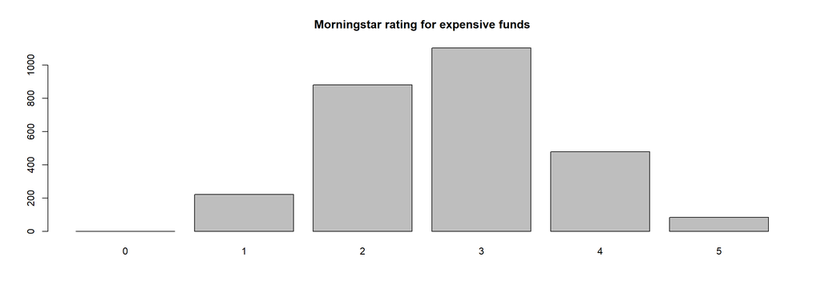

```r
barplot(summary(mutual_funds_expensive$morningstar_rating),main='Morningstar rating for expensive funds')
```

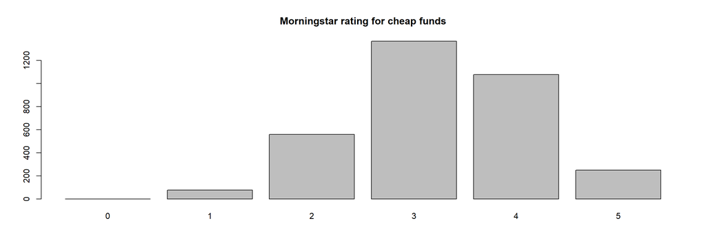

```r
barplot(summary(mutual_funds_cheap$morningstar_rating),main='Morningstar rating for cheap funds')
```

```r
expensive_rating <- table(mutual_funds_expensive$morningstar_rating)
cheap_rating <-table(mutual_funds_cheap$morningstar_rating)
round(prop.table(expensive_rating),digits=2)
```

```
##
##    0    1    2    3    4    5
## 0.00 0.08 0.32 0.40 0.17 0.03
```

```r
round(prop.table(cheap_rating),digits=2)
```

```
##
##    0    1    2    3    4    5
## 0.00 0.02 0.17 0.41 0.32 0.08
```

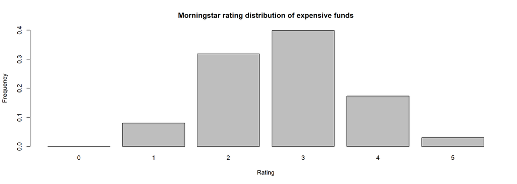

```r
barplot(prop.table(expensive_rating), xlab='Rating',ylab='Frequency',main="Morningstar rating distribution of expensive funds",ylim=range(pretty(c(0,prop.table(expensive_rating)))))
```

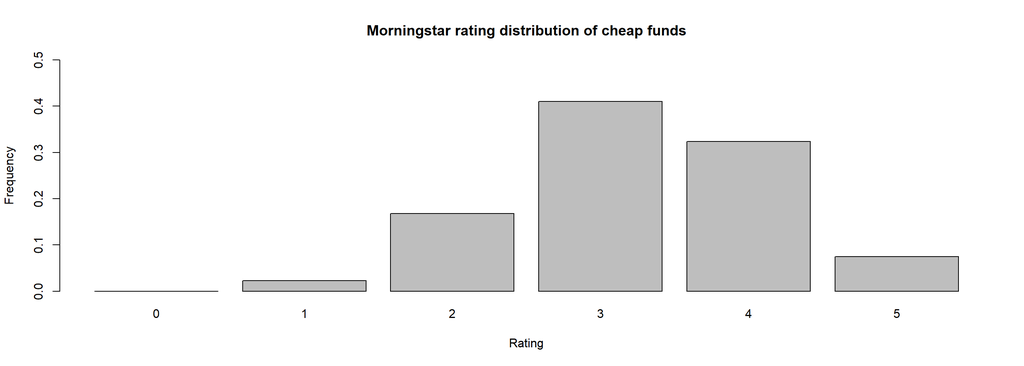

```r
barplot(prop.table(cheap_rating), xlab='Rating',ylab='Frequency',main="Morningstar rating distribution of cheap funds",ylim=range(pretty(c(0,prop.table(cheap_rating)))))
```

Test proporcija

```r
expensive_high_ratings = expensive_rating[["4"]][1] + expensive_rating[["5"]][1]
expensive_collective = expensive_rating[["1"]][1] + expensive_rating[["2"]][1] + expensive_rating[["3"]][1] + expensive_rating[["4"]][1] + expensive_rating[["5"]][1]
expensive_high_ratings
```

```
## [1] 563
```

```r
expensive_collective
```

```
## [1] 2769
```

```r
cheap_high_ratings = cheap_rating[["4"]][1] + cheap_rating[["5"]][1]
cheap_collective = cheap_rating[["1"]][1] + cheap_rating[["2"]][1] + cheap_rating[["3"]][1] + cheap_rating[["4"]][1] + cheap_rating[["5"]][1]
cheap_high_ratings
```

```
## [1] 1327
```

```r
cheap_collective
```

```
## [1] 3328
```

```r
rating_proportions <- c(cheap_high_ratings,expensive_high_ratings)
rating_sum <- c(cheap_collective,expensive_collective)
prop.test(rating_proportions,rating_sum, alt="greater")
```

```
##
##  2-sample test for equality of proportions with continuity correction
##
## data:  rating_proportions out of rating_sum
## X-squared = 268.93, df = 1, p-value < 2.2e-16
## alternative hypothesis: greater
## 95 percent confidence interval:
##  0.1762917 1.0000000
## sample estimates:
##    prop 1    prop 2
## 0.3987380 0.2033225
```

Odbacujemo hipotezu H_0 da su proporcije visoko rangiranih fondova jednake kod skupljih i jeftinijih fondova. Možemo zaključiti da jeftiniji fondovi imaju veću proporciju visoko rangiranih fondova.

Sada možemo istražiti povezanost cijene i uspjeha pomoću linearne regresije.

Prvo scatter plotove

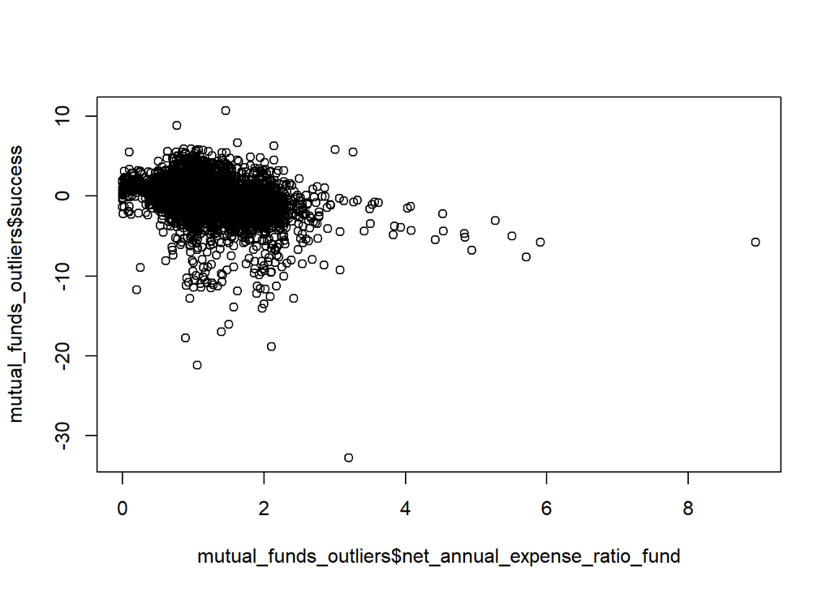

```r
plot(mutual_funds_outliers$net_annual_expense_ratio_fund,mutual_funds_outliers$success)
```

Zatim radimo regresijski model

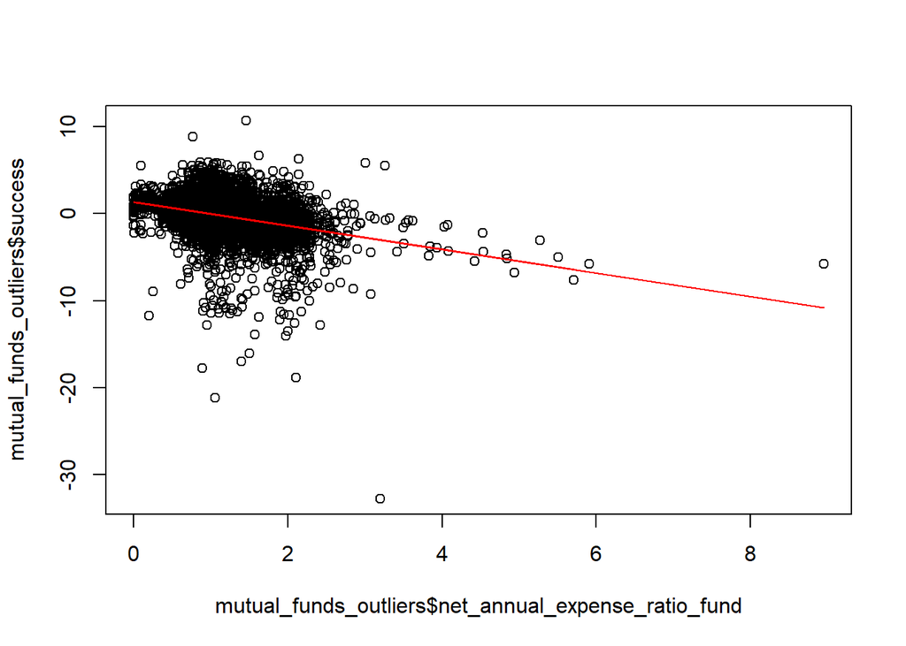

```r
fit.expense = lm(success~net_annual_expense_ratio_fund, data = mutual_funds_outliers)

plot(mutual_funds_outliers$net_annual_expense_ratio_fund,mutual_funds_outliers$success)
lines(mutual_funds_outliers$net_annual_expense_ratio_fund,fit.expense$fitted.values,col='red')
```

Nagib pravca nam daje potvrđuje pretpostavku. Potrebno je analizirati pretpostavke modela

Prvo analiziramo normalnost reziduala

```r
selected.model = fit.expense
require(e1071)
kurtosis(selected.model$residuals)
```

```
## [1] 16.96193
```

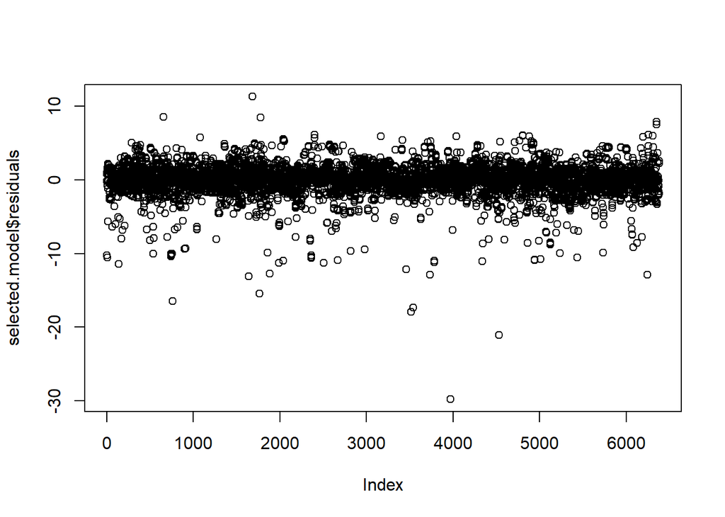

```r
plot(selected.model$residuals) #gledajuci reziduale na ovaj nacin tesko je suditi o normalnosti
```

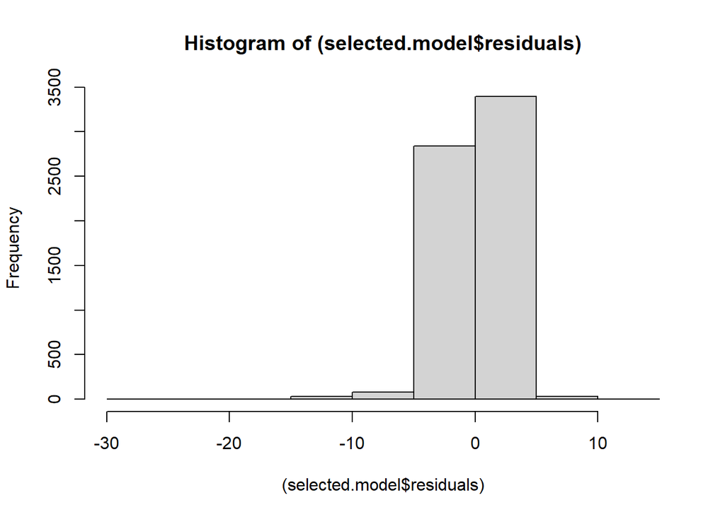

```r
#histogram je vrlo interpretativan
hist((selected.model$residuals))
```

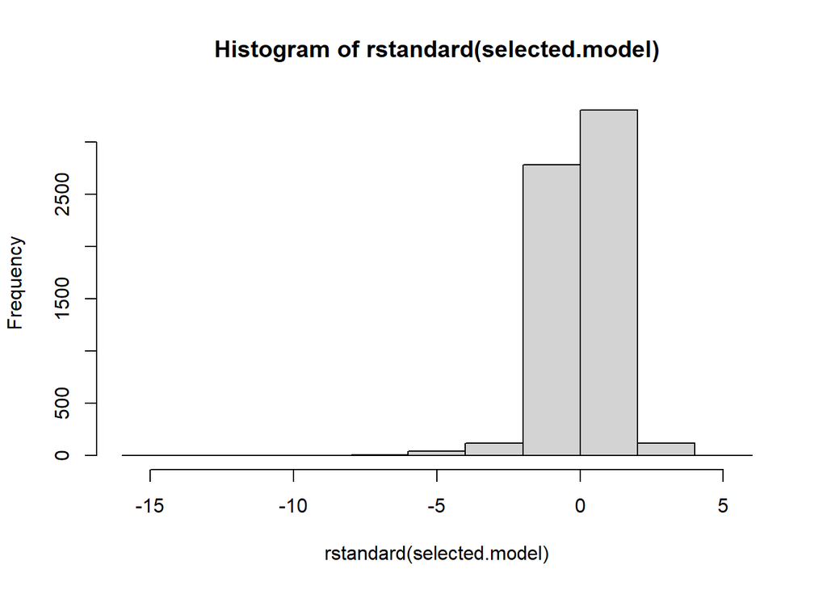

```r
hist(rstandard(selected.model))
```

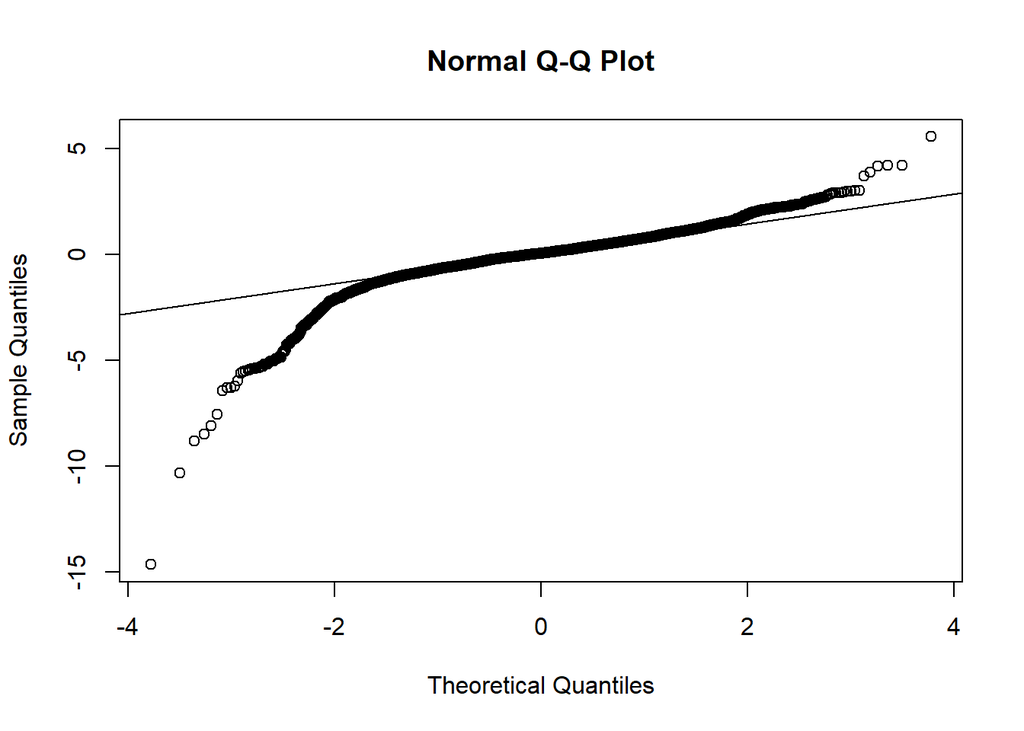

```r
#q-q plot reziduala s linijom normalne distribucije
qqnorm(rstandard(selected.model))
qqline(rstandard(selected.model))
```